# Ozlem Akekmekci_IE582_HW3

## *Ozlem Akekmekci*

### *December 6,2021*

In this homework, there are 2 different tasks in which we use the same data of the gesture recognition in Homework2. We evaluate train-test performances by using different learning methods.

In task 1, we used two different distance measures. Euclidean and Manhattan distances are the ones I chose as different distance measures. We applied k-nearest-neighbor (kNN) classifier to the concetanated version of the gesture data. By using 10-fold cross-validation, we find the optimal value of K that minimizes the error. And then, by using this level of k, we evaluate the performance on test data.

In task2, to predict the gestures from Class 3 in a binary setting, we applied logistic regression with and without penalization and also find the optimal level of lambda parameter. With the best lambda value, we performed classification again. In the third part of this task, we used distance matrix as a feature matrix in the same model to introduce nonlinear relations. By using Euclidean distance, we perform the same strategy. Then in the final part, we evaluated all of these methods.

## **TASK 1 - On the use of distance information for UwaveGesture Recognition Task**

##A

```r
trainX = as.matrix(read.table("uWaveGestureLibrary_X_TRAIN"))
trainY = as.matrix(read.table("uWaveGestureLibrary_Y_TRAIN"))
trainZ = as.matrix(read.table("uWaveGestureLibrary_Z_TRAIN"))
testX = as.matrix(read.table("uWaveGestureLibrary_X_TEST"))
testY = as.matrix(read.table("uWaveGestureLibrary_Y_TEST"))
testZ = as.matrix(read.table("uWaveGestureLibrary_Z_TEST"))

train = matrix(0, 896, 946) #concetaneted as in HW2 - train
train[,1:316] = trainX[,1:316]
train[,317:631] = trainY[,2:316]
train[,632:946] = trainZ[,2:316]

test = matrix(0, 3582, 946) #concetaneted as in HW2 - test
test[,1:316] = testX[,1:316]
test[,317:631] = testY[,2:316]
test[,632:946] = testZ[,2:316]

library(TunePareto) #for generateCVRuns
library(FastKNN) #for knn_test_function
library(data.table)
testLength = nrow(test) #will be used while generating distance matrices afterwards.
trainLength = nrow(train)

set.seed(80)
trainClass = as.matrix(train[,1]) #since first columns consist the class information.
testClass = as.matrix(test[,1])
kLev = c(1:10) #number of neighbors
folds = 10    #10-fold CV, as given in the question.
#number of replications is set to be 1 for simplicity.
```

First, I have defined the number of neighbors, folds and replications that will be used in this task.

Also, in the KNN function that will be performed afterwards, we need to use euclidean and distance matrices based on the training data. So, I created these matrices by using the Euclidean and Manhattan distance formulas.

```r
euclideanTrain = matrix(rep(0,trainLength^2),trainLength)  #euclidean distance matrix
for(i in 1:trainLength)
  for(j in 1:trainLength)
    euclideanTrain[j,i] = sqrt(sum((train[i,]-train[j,])^2))


manhattanTrain = matrix(rep(0,trainLength^2),trainLength)  #manhattan distance matrix
for(i in 1:trainLength)
  for(j in 1:trainLength)
    manhattanTrain[j,i] = sum(abs(train[i,]-train[j,]))
```

To perform cross-validation, we need to generate different random partitions from the training data. These partitions are generated by using the information of gesture classes given in the training data add to number of repetitions and folds.

```r
partitions = generateCVRuns(trainClass, ntimes = 1, nfold = 10, leaveOneOut = FALSE, stratified = FALSE)
```

Below, kNN with Euclidean distance measure is shown.

```r
i=1 #since number of replications is set to be 1.

cvEuc=data.table()  #blank data table
for(j in 1:folds)
{
  testIndices=partitions[[i]][[j]] #by using the partitions generated above.
  cvTrain=train[-testIndices,] #creating CV test and training data
  cvTest=train[testIndices,]

  for(k in kLev)
  {
    knnEuc=knn_test_function(cvTrain,cvTest, euclideanTrain[testIndices,-testIndices],trainClass[-testIndices],k=k)
    cvEuc=rbind(cvEuc,data.table(replication=i,fold=j,method='knn',kLev=k,testID=testIndices, predictions=as.numeric(as.character(knnEuc)), real=trainClass[testIndices]))
  }
}
```

Then, we can calculate the accuracy of CV for each k level.

```r
cvEuc[,list(accuracy=mean(predictions==real)),by=kLev]
```

```
##     kLev  accuracy
##  1:    1 0.9285714
##  2:    2 0.9229911
##  3:    3 0.9252232
##  4:    4 0.9341518
##  5:    5 0.9341518
##  6:    6 0.9308036
##  7:    7 0.9252232
##  8:    8 0.9241071
##  9:    9 0.9274554
## 10:   10 0.9241071
```

As seen above, Euclidean model performs best when k=4 and k=5, accuracy for these k levels are exactly the same and almost 93.42%.

Finally, we do the same for the kNN with Manhattan distance measure.

```r
cvMan=data.table()
for(j in 1:folds)
{
  testIndices=partitions[[i]][[j]]

  cvTrain=train[-testIndices,]
  cvTest=train[testIndices,]

  for(k in kLev)
  {
    knnMan=knn_test_function(cvTrain,cvTest, manhattanTrain[testIndices,-testIndices],trainClass[-testIndices],k=k)
    cvMan=rbind(cvMan,data.table(replication=i,fold=j,Method='knn',kLev=k,testID=testIndices, predictions=as.numeric(as.character(knnMan)), real=trainClass[testIndices]))
  }
}

cvMan[,list(accuracy=mean(predictions==real)),by=kLev]
```

```
##     kLev  accuracy
##  1:    1 0.9352679
##  2:    2 0.9263393
##  3:    3 0.9419643
##  4:    4 0.9453125
##  5:    5 0.9464286
##  6:    6 0.9363839
##  7:    7 0.9341518
##  8:    8 0.9352679
##  9:    9 0.9285714
## 10:   10 0.9319196
```

##B

In part A, I found the ideal values of k for each distance measure. For Euclidean, k=4 and k=5 For Manhattan, k=5

Then by using these values, I performed a prediction on the test data.

```r
#Euclidean, k=4,

euclideanDistance = matrix(rep(0,testLength*trainLength),ncol=trainLength)  #Euclidean distance matrix for the distances between test and training data

for(i in 1:trainLength)
  for(j in 1:testLength)
    euclideanDistance[j,i] = sqrt(sum((train[i,]-test[j,])^2))


euclideanPred = as.numeric(knn_test_function(train,test,euclideanDistance,trainClass,k=4)) #predictions
euclideanAccur= sum(euclideanPred==testClass)/testLength
euclideanAccur #accuracy for Euclidean model
```

```
## [1] 0.9271357
```

```r
table(euclideanPred,testClass) #confusion matrix for Euclidean model
```

```
##              testClass
## euclideanPred   1   2   3   4   5   6   7   8
##             1 426   1   0   1   3   6   0   0
##             2   0 449   0   0   0   0   0   0
##             3   0   0 398   0   6   8   4   0
##             4   4   0   1 353   2  20   0   0
##             5   0   0  25  73 420  38   0   2
##             6   7   0  24  16   2 375   1   0
##             7   0   2   5   0   0   1 442   0
##             8   0   0   1   7   0   1   0 458
```

```r
timeEuclidean = system.time(knn_test_function(train,test,euclideanDistance,trainClass,k=4))
timeEuclidean #runtime for the Euclidean model
```

```
##    user  system elapsed
##    3.05    0.00    3.19
```

```r
#Manhattan, k=5,

manhattanDistance = matrix(rep(0,testLength*trainLength),ncol=trainLength)  #Manhattan distance matrix for the distances between test and training data

for(i in 1:trainLength)
  for(j in 1:testLength)
    manhattanDistance[j,i] = sum(abs(train[i,]-test[j,]))

manhattanPred = as.numeric(knn_test_function(train,test,manhattanDistance,trainClass,k=5))
manhattanAccur = sum(manhattanPred==testClass)/testLength
manhattanAccur #accuracy for the Manhattan model
```

```
## [1] 0.9369068
```

```r
table(manhattanPred,testClass) #confusion matrix for Manhattan model
```

```
##              testClass
## manhattanPred   1   2   3   4   5   6   7   8
##             1 425   1   0   3   4   7   1   0
##             2   0 451   0   0   0   0   0   0
##             3   0   0 409   0   5   6   5   1
##             4   4   0   1 374   2  18   0   2
##             5   0   0  22  59 421  38   0   2
##             6   8   0  16   7   1 380   0   0
##             7   0   0   6   0   0   0 441   0
##             8   0   0   0   7   0   0   0 455
```

```r
timeManhattan = system.time(knn_test_function(train,test,manhattanDistance,trainClass,k=5))
timeManhattan #runtime for the Manhattan model
```

```
##    user  system elapsed
##    1.85    0.00    1.88
```

##C

I think the decision between weighting equally or differently depend on the data structure we work with. For the gesture data, it may be reasonable to compute the distance with different weights over different axes. As in HW2, when we apply PCA, for each component/latent variable, we weight the information from each axes differently. And, we explained most of the variances by using only 2 components. We didn’t need to use all dimensions to explain the variation in gesture data, so we didn’t equally weight the information coming from each axes. So, it may be reasonable to weight differently the distance information of each axes may be reasonable in gesture data.

## **TASK 2 - Linear models on alternative representations of the data**

```r
library("caTools") #for logistic regression
library(data.table)
library(glmnet)
library(glmpathcr)
```

##A

To perform binary classification on Class3 information, we generate binary variables in both test and training data.

```r
classificationTrain = as.data.table(copy(train))
classificationTrain [,three:=as.numeric(V1==3)]
classificationTrain [,V1:=NULL]

classificationTest = as.data.table(copy(test))
classificationTest [,three:=as.numeric(V1==3)]
classificationTest [,V1:=NULL]
```

Then, we train a logistic regression model on the training data.

As given in the question, due to imbalanced class setting, we need to define threshold level that equals to the ratio of Class 3 instances rather than 0.5.

```r
ratio = sum(classificationTrain$three)/nrow(classificationTrain) #ratio of the class3 instances in the training data
ratio
```

```
## [1] 0.1183036
```

```r
trainn = as.data.table(train)
testt=as.data.table(test)

model = glm(three~., classificationTrain, family="binomial")
probabilities =  predict(model,classificationTest, type = "response")
predicted = ifelse(probabilities>ratio, "1", "0")

table(classificationTest$three, predicted)  #confusion matrix
```

```
##    predicted
##        0    1
##   0 1656 1472
##   1  209  245
```

```r
mean(predicted==classificationTest$three)   #accuracy
```

```
## [1] 0.5307091
```

As we can see from both the confusion matrix and the accuracy value (0.5307), this model does not predict well the binary classification of class 3.

##B

We use cv.glmnet function to perform 1*-fold-cross validation for with the different values. Then, we can evaluate the approach at different values. I don’t define any values so it finds value that uses all features. Since we define 10-fold, it builsd 10 models with these different values and test the data.

To train a logistic regression model with lasso penalties, we set the elasticnet mixing parameter as 1, which makes the penalties lasso.

```r
set.seed(60)
x = model.matrix(three~., classificationTrain)
lasso = cv.glmnet(x, classificationTrain$three, family="binomial", alpha=1, nfolds=10, type.measure="deviance") #alpha=1 due to Lasso
```

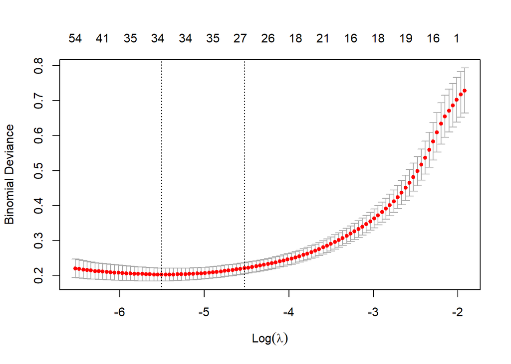

```r
plot(lasso)
```

This plot gives information about the binomial deviances during the CV runs and kind of a confidence intervals of these deviances.

Lambda.min gives the value of minimum mean CV error. This value gives the most accurate model which minimizes the prediction error.

```r
lasso$lambda.min
```

```
## [1] 0.004074776
```

Lambda.1se gives the simplest model which also lies within one standard error of the optimal value of lambda. This value is related to the discussion of overfitting and underfitting.

```r
lasso$lambda.1se
```

```
## [1] 0.01082296
```

Since lambda.min value gives the mosy accurate results, it is the best value and we build a model by using this value and perform a prediction accordingly.

```r
lasso
```

```
##
## Call:  cv.glmnet(x = x, y = classificationTrain$three, type.measure = "deviance",      nfolds = 10, family = "binomial", alpha = 1)
##
## Measure: Binomial Deviance
##
##       Lambda Index Measure      SE Nonzero
## min 0.004075    78  0.2027 0.01856      33
## 1se 0.010823    57  0.2208 0.01588      27
```

Even though lambda.min value minimizes the error, since we have lower number of nonzero varibles in 1se, we can select this to avoid overfitting. So, I will perform predictions using both lambda.min and lambda.1se values.

```r
#final model and prediction on the test data with lambdamin
lassoMin = glmnet(x, classificationTrain$three, alpha=1, family="binomial", lambda=lasso$lambda.min)
test = model.matrix(three~., classificationTest)
probabilities2 = predict(lassoMin, test)
predicted2 = ifelse(probabilities2>ratio, "1", "0")

table(classificationTest$three, predicted2)  #confusion matrix
```

```
##    predicted2
##        0    1
##   0 3051   77
##   1  128  326
```

```r
coef1=coef(lassoMin, lasso$lambda.min)
coef1[coef1[,1]!=0,] #to show only the nonzero coefficients
```

```
## (Intercept)         V18         V44         V51         V89        V145
## -5.02401806 -0.09415204 -0.43559918 -0.05166043 -0.25208854 -0.05868119
##        V211        V235        V236        V237        V238        V250
##  0.12714987  0.38513316  0.25372241  0.29288482  0.09106106  0.18822968
##        V259        V283        V291        V296        V316        V328
##  0.55969824  0.84641448  0.24476453  0.12052773  0.63397826 -0.15683455
##        V329        V335        V476        V482        V508        V542
## -0.09765780 -0.14329124  0.01361657  1.22169963  0.60367346  0.10977307
##        V719        V730        V810        V811        V822        V888
##  0.11031490  0.35306765 -0.08821570 -0.52297335 -0.02436534 -0.12654894
```

```r
mean(predicted2==classificationTest$three) ##accuracy
```

```
## [1] 0.9427694
```

```r
#final model and prediction on the test data with lambda1se
lasso1se = glmnet(x, classificationTrain$three, alpha=1, family="binomial", lambda=lasso$lambda.1se)
test = model.matrix(three~., classificationTest)
probabilities3 = predict(lasso1se, test)
predicted3 = ifelse(probabilities3>ratio, "1", "0")

table(classificationTest$three, predicted3)  #confusion matrix
```

```
##    predicted3
##        0    1
##   0 3056   72
##   1  135  319
```

```r
coef2 = coef(lasso1se, s=lasso$lambda.1se)
coef2[coef2[,1]!=0,] #to see only the nonzero coefficients
```

```
##   (Intercept)           V20           V44           V45           V57
## -3.6975934686 -0.0708363259 -0.2288880040 -0.0168417851 -0.0132670652
##           V88           V89          V211          V235          V236
## -0.0316483378 -0.1029896338  0.0798465656  0.5102321310  0.2142453258
##          V237          V251          V252          V259          V260
##  0.1088735692  0.0261902671  0.0389742522  0.5003665817  0.0148009374
##          V283          V296          V316          V336          V476
##  0.7732808618  0.2311752433  0.4199845783 -0.0383941505  0.0772201811
##          V482          V490          V508          V719          V720
##  0.8853130492  0.0520204092  0.4878297893  0.0002126314  0.0167834385
##          V729          V730          V814          V822
##  0.1501461148  0.1201946991 -0.1199709225 -0.0629403455
```

```r
mean(predicted3==classificationTest$three) ##accuracy
```

```
## [1] 0.9422111
```

##C

```r
eucTrain = matrix(0,trainLength,trainLength)
for(i in 1:trainLength)
  for(j in 1:trainLength)
    eucTrain[j,i] = sqrt(sum((train[i,]-train[j,])^2))


lassoC = glmnet(eucTrain, classificationTrain$three, alpha=1, family="binomial", lambda=lasso$lambda.min)


eucTest = matrix(0, nrow=testLength, ncol=trainLength)

for(i in 1:trainLength)
  for(j in 1:testLength)
    eucTest[j,i] = sqrt(sum((train[i,]-test[j,])^2))


probabilities4 = predict(lassoC, eucTest)
predicted4 = ifelse(probabilities2>ratio, "1", "0")
table(classificationTest$three, predicted4)  #confusion matrix
```

```
##    predicted4
##        0    1
##   0 3051   77
##   1  128  326
```

```r
mean(predicted4==classificationTest$three) ##accuracy
```

```
## [1] 0.9427694
```

```r
coef3=coef(lassoC, lasso$lambda.min)
coef3[coef3[,1]!=0,] #to show only the nonzero coefficients
```

```
##   (Intercept)            V4          V112          V130          V138
## 41.2979674515 -0.0231601238 -0.0686498111 -0.0001005950  0.0044679878
##          V189          V210          V223          V320          V372
## -0.0519348067 -0.0083088016  0.0029361584 -0.0591976891  0.0468110718
##          V394          V424          V441          V450          V515
## -0.0461105096 -0.0934863555 -0.0061579827 -0.1673230408 -0.0922256468
##          V521          V536          V605          V646          V723
## -0.0784484213 -0.1772116613 -0.0003187834 -0.0556933114 -0.0595515003
##          V732          V746          V808          V833          V834
## -0.1286401955 -0.0177767884 -0.0683895145 -0.0819800078  0.0393442955
##          V883          V888          V891
## -0.0189679174 -0.0068953949  0.1262251216
```

##D